# Visual Analytics for Insurance Portfolio Data Discovery

Executive Summary: Spanish Motor Vehicle Insurance Portfolio

Lei Yuhe

2026-05-24

## Contents

| # | Topic |
| --- | --- |
| 1 | Portfolio Overview & Data Context |
| 2 | Premium Distribution: Right-Skewed Pricing |
| 3 | Claim Severity: Log-Normal Structure |
| 4 | Loss Ratio: Portfolio Profitability Profile |
| 5 | Policy Type: Who Drives Losses? |
| 6 | Driver Age: Lifecycle Risk Patterns |
| 7 | Geography & Fuel Type: Loss Ratio Heatmap |
| 8 | Bonus Score: Past Claim Experience as a Signal |
| 9 | Vehicle Age & Loss Ratio: Risk Bubble Chart |
| 10 | Business Type & Payment Frequency: Behavioural Signals |
| 11 | Key Takeaways & Recommendations |

## Slide 1: Portfolio Overview

**Dataset at a Glance**

- **Source:** Mendeley Data, a real Spanish non-life insurer
- **Policy years:** 2022–2024
- **Key variables:** 21 fields per policy record
- **Loss Ratio** = Incurred / Premium *(profitability)*
- **Claim Frequency** = Claims / Exposure *(volatility)*

**Data Quality**

| Variable | Missing |
| --- | --- |
| `fuel_type` | 1,287 |
| `vehicle_value` | 513 |
| `loss_ratio` | 48 |

**Outlier Treatment**

Insurance data is naturally heavy-tailed. Policies beyond the **99th percentile** were excluded from primary charts:

- Loss Ratio 99th percentile = **12.37**, 3,541 policies flagged
- Claim Frequency 99th percentile = **5**, 3,052 policies flagged

Filtering improves visual interpretability without ignoring tail risk.

## Slide 2: Premium Distribution is Right-Skewed

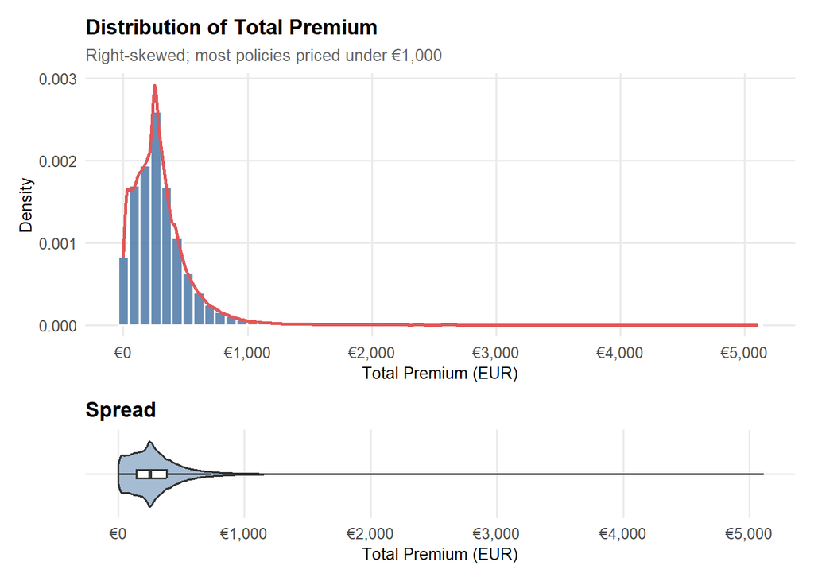

**Key Findings**

- Distribution is strongly **right-skewed**, most policyholders pay under **€1,000**
- Long right tail reflects policies covering **high-value vehicles** and **comprehensive coverage**

## Slide 3: Claim Distribution is Right-Skewed

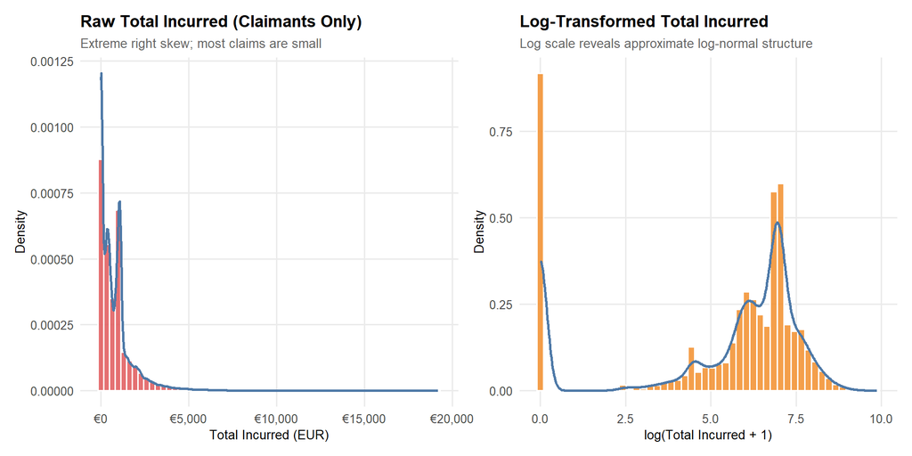

**Key Findings**

- Most policies record **zero claims**, the majority of incurred cost is driven by a minority
- Log-transformed distribution shows an **approximately log-normal** pattern

## Slide 4: Portfolio Profitability Profile (Loss Ratio)

**What is Loss Ratio (LR)?** `LR = Total Incurred / Total Premium`

- **LR < 1**: Profitable
- **LR = 1**: Break-even
- **LR > 1**: Unprofitable

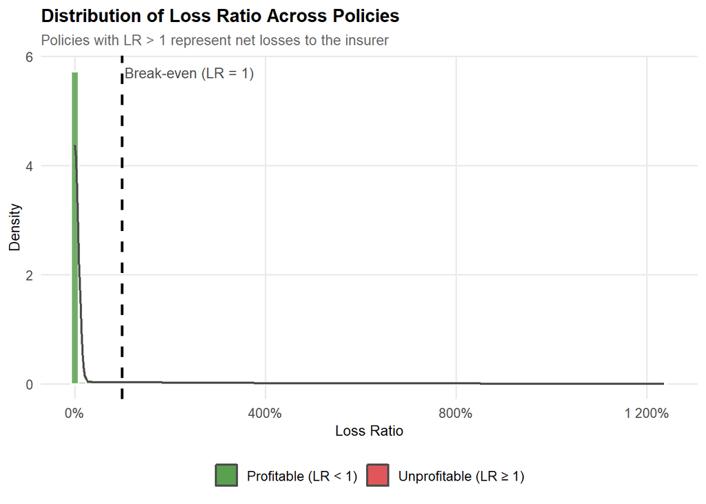

**Key Findings**

- Distribution is **bimodal**: a massive spike at 0 and a long right-tail for claimants
- After 99th pct filtering, LR extends to ~12

## Slide 5: Policy Type: Who Drives the Losses?

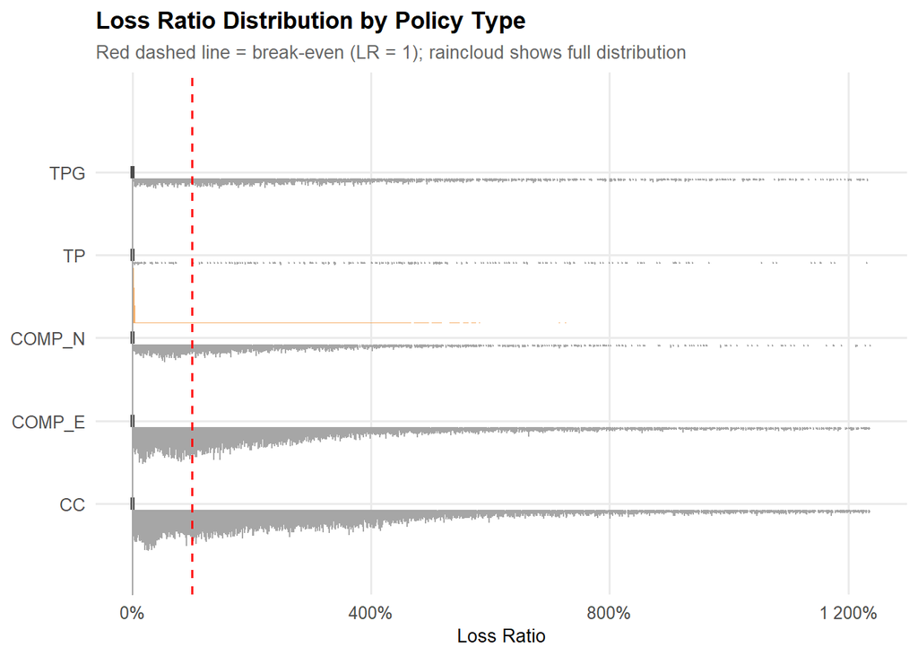

**Policy Types in Portfolio**

| Type | Coverage | Risk |
| --- | --- | --- |
| COMP_E | Comprehensive + excess | High |
| COMP_N | Comprehensive, no excess | Medium |
| CC | Comprehensive third party | High |
| TPG | Third Party + Glass | Low |
| TP | Third Party Only | Lowest |

[figure not shown]

## Slide 7: Geography & Fuel Type Loss Ratio Heatmap

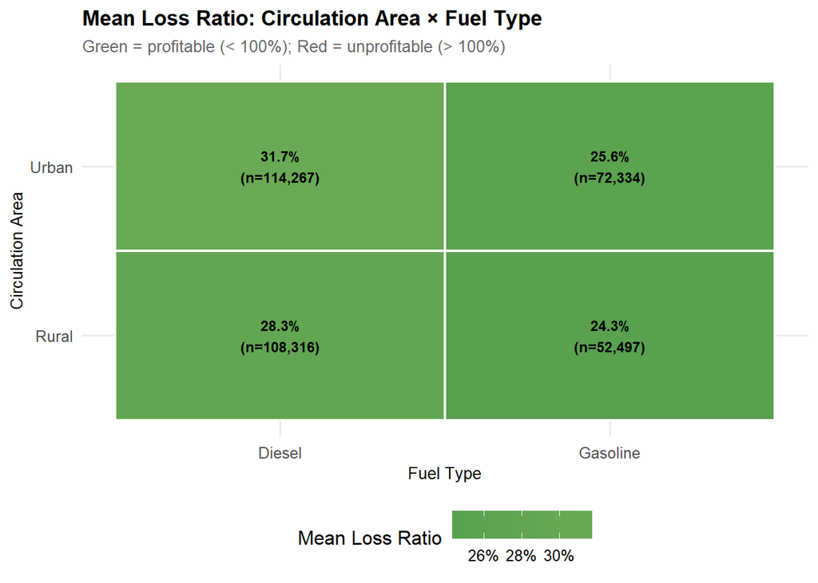

**Key Findings**

Heatmap cells encode mean Loss Ratio.

- **Urban** policies consistently generate higher loss ratios than rural’s
- **Diesel** vehicles display higher loss ratios than gasoline regardless of area, suggesting higher vehicle utilisation or claim severity

## Slide 8: Bonus Score (Past Claims as a Signal)

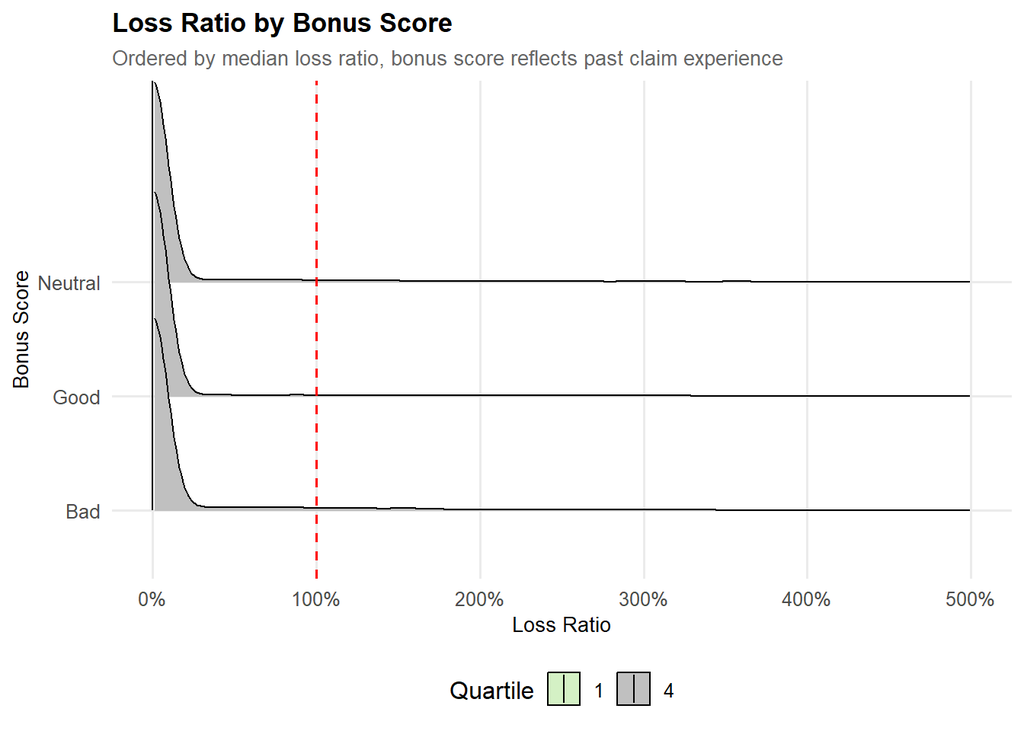

**Key Findings**

**Bonus score** reflects a policyholder’s past claim experience.

- Majority of policies remain profitable regardless of bonus category
- All groups display strong right-skewness, meaning a relatively small number of policies generate disproportionately large claim costs and underwriting losses

## Slide 9: Vehicle Age & Loss Ratio in Bubble Chart

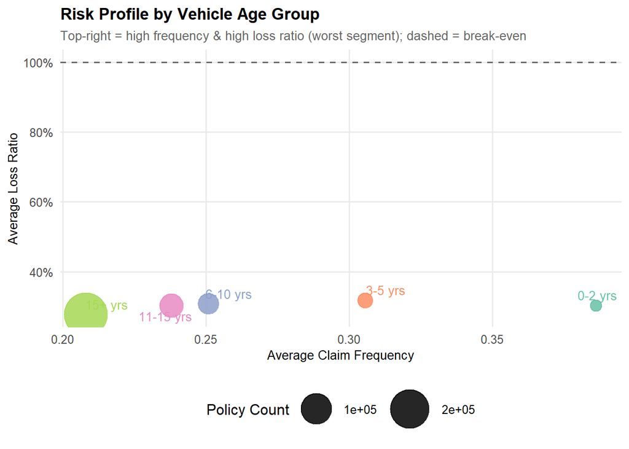

**Key Findings**

- **Newer vehicles (0–2 years)** exhibit the highest claim frequency, indicating that recently purchased vehicles are associated with more frequent claim activity, although their average loss ratios remain relatively stable.
- **Older vehicles (15+ years)** show the lowest claim frequency and relatively low loss ratios, while also representing one of the largest policy segments, suggesting a stable and profitable customer group.
- Vehicle age alone is not sufficient in explaining loss ratio.

## Slide 10: Business Type & Payment Frequency

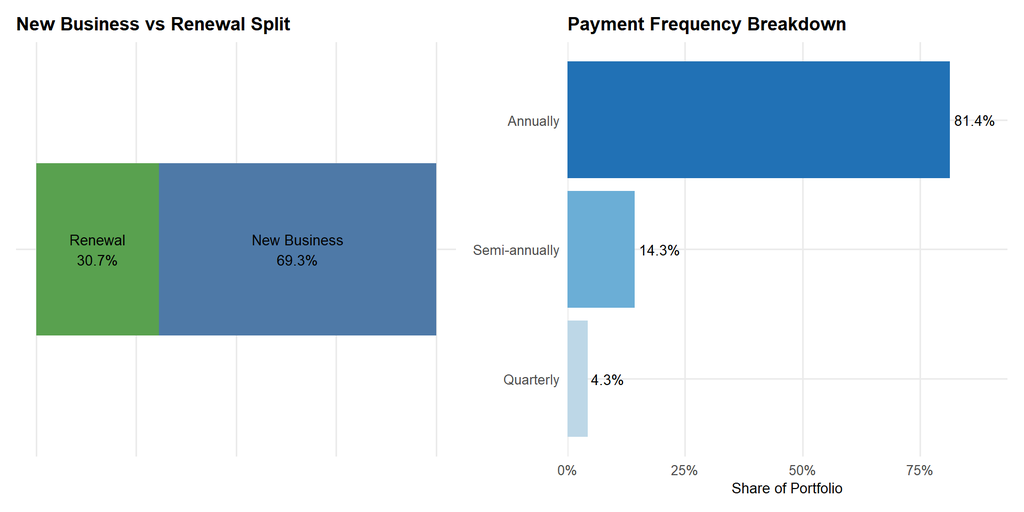

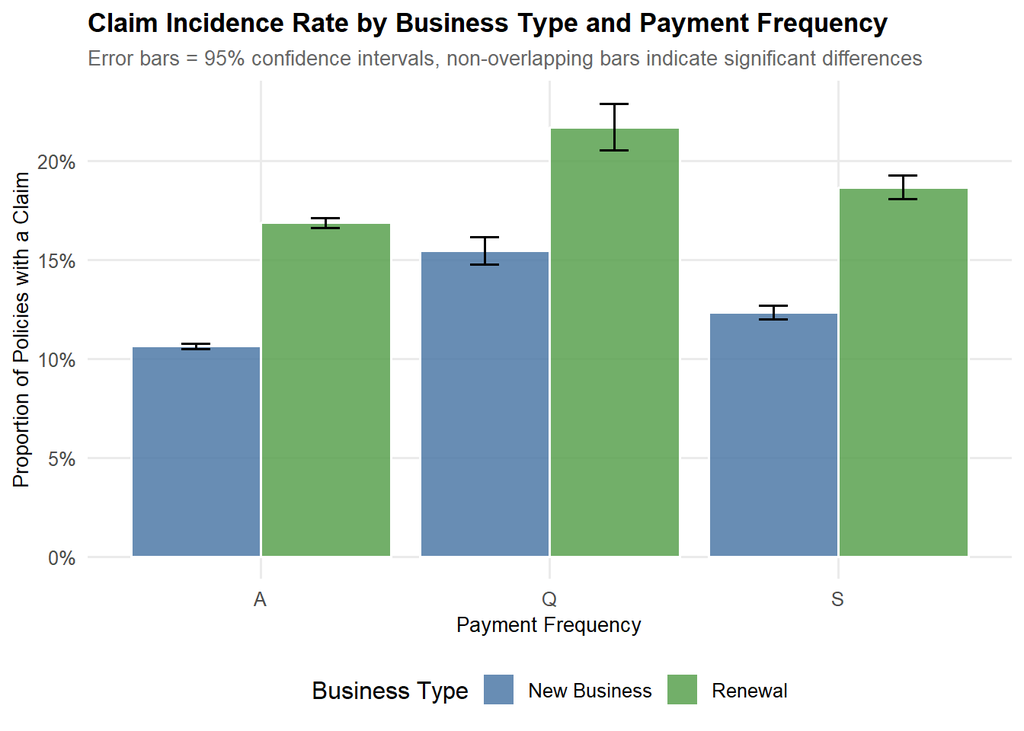

**Key Findings**

- The portfolio is heavily dominated by **New Business policies (69.3%)** and **annual payment plans (81.4%)**, indicating a growth-oriented portfolio structure
- **Renewal customers** driving higher claim incidence rates
- Payment frequency may act as a behavioural or financial risk indicator useful for underwriting and customer segmentation

## Slide 11: Key Takeaways & Recommendations

**Recommendations**

1. Strengthen Risk-Based Pricing: The insurer should apply more granular pricing adjustments for comprehensive policyholders, urban drivers, and high-risk age groups.
2. Develop targeted underwriting rules for high-risk customer segments.
3. Since a small number of policies generate disproportionately large losses, the insurer should strengthen fraud detection and improve catastrophic claims monitoring.